# Homework 05

STAT 430, Fall 2017

Due: Friday, October 13, 11:59 PM

Please see the [homework instructions document](https://daviddalpiaz.github.io/stat430fa17/homework_policy.html) for detailed instructions and some grading notes. Failure to follow instructions will result in point reductions.

# Exercise 1 (Detecting Cancer with KNN)

**[7 points]** For this exercise we will use data found in `wisc-trn.csv` and `wisc-tst.csv` which contain train and test data respectively. `wisc.csv` is provided but not used. This is a modification of the Breast Cancer Wisconsin (Diagnostic) dataset from the UCI Machine Learning Repository. Only the first 10 feature variables have been provided. (And these are all you should use.)

- UCI Page
- [Data Detail](https://archive.ics.uci.edu/ml/machine-learning-databases/breast-cancer-wisconsin/wdbc.names)

You should consider coercing the response to be a factor variable. Use KNN with all available predictors. For simplicity, do not scale the data. (In practice, scaling would slightly increase performance on this dataset.) Consider $k = 1, 3, 5, 7, \ldots, 51$. Plot train and test error vs $k$ on a single plot.

Use the seed value provided below for this exercise.

```r
set.seed(314)
```

```r
library(readr)
wisc_trn = read.csv('wisc-trn.csv')
wisc_tst = read.csv('wisc-tst.csv')
```

```r
x_trn = wisc_trn[,-1]
y_trn = wisc_trn$class
x_tst = wisc_tst[,-1]
y_tst = wisc_tst$class

calc_class_err = function(actual, predicted) {
  round(mean(actual != predicted),7)
}

k = seq(1,51,2)
trn_error = rep(x = 0, times = length(k))
tst_error = rep(x = 0, times = length(k))
```

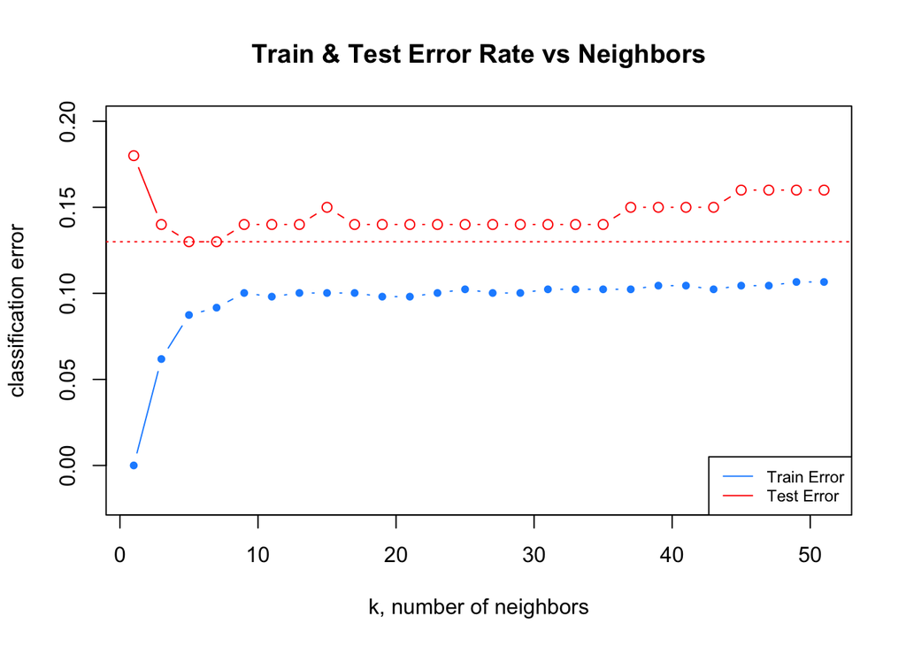

```r
library(FNN)
for (i in 1:length(k)){
  trn_pred = knn(train = x_trn, test = x_trn, cl = y_trn, k = k[i])
  tst_pred = knn(train = x_trn, test = x_tst, cl = y_trn, k = k[i])
  trn_error[i] = calc_class_err(y_trn, trn_pred)
  tst_error[i] = calc_class_err(y_tst, tst_pred)
}

plot(k, trn_error, type = "b", col = "dodgerblue", cex = 1, pch = 20,
 ylim = c(min(c(trn_error, tst_error)) - 0.02, max(c(trn_error,    tst_error)) + 0.02),xlab = "k, number of neighbors", ylab = "classification error",
main = "Train & Test Error Rate vs Neighbors")
lines(k, tst_error, type = "b", col = "red")

abline(h = min(tst_error), col = "red", lty = 3)
 legend("bottomright",c("Train Error","Test Error"),
 col=c("dodgerblue","red"),
       cex=0.75,
       lty=c(1,1))
```

# Exercise 2 (Logistic Regression Decision Boundary)

**[5 points]** Continue with the cancer data from Exercise 1. Now consider an additive logistic regression that considers only two predictors, `radius` and `symmetry`. Plot the test data with `radius` as the $x$ axis, and `symmetry` as the $y$ axis, with the points colored according to their tumor status. Add a line which represents the decision boundary for a classifier using 0.5 as a cutoff for predicted probability.

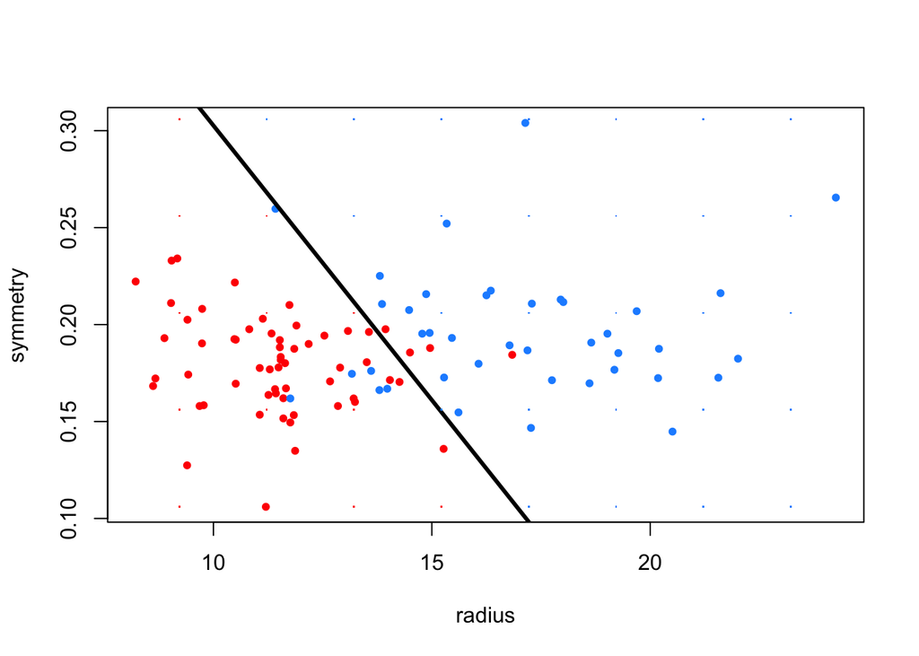

```r
glm1 = glm(class~radius+symmetry, data = wisc_tst, family = "binomial")

boundary_line = function(model){
  intercept = as.numeric(-coef(model)[1]/coef(model)[3])
  slope = as.numeric(-coef(model)[2]/coef(model)[3])
  c(intercept = intercept, slope = slope)
}

add_boundary = function(model, line_col = "black") {
  abline(boundary_line(model), col = line_col, lwd = 3)
}

intercept = boundary_line(glm1)[1]
slope = boundary_line(glm1)[2]

rad = seq(min(wisc_tst$radius) - 5, max(wisc_tst$radius) + 5, by = 2)
sym = seq(min(wisc_tst$symmetry) - 0.1, max(wisc_tst$symmetry) + 0.1, by = 0.05)
grid = expand.grid(rad = rad, sym = sym)
background = ifelse(grid$sym > intercept + slope * grid$rad,
                    "dodgerblue",
                    "red")
class_color = ifelse(wisc_tst$class == 'B', "red", "dodgerblue")
plot(symmetry ~ radius,
     data = wisc_tst,
     col = class_color,
     pch = 20)
add_boundary(glm1)
points(expand.grid(rad, sym), col = background, pch = ".")
```

# Exercise 3 (Sensitivity and Specificity of Cancer Detection)

**[5 points]** Continue with the cancer data from Exercise 1. Again consider an additive logistic regression that considers only two predictors, `radius` and `symmetry`. Report test sensitivity, test specificity, and test accuracy for three classifiers, each using a different cutoff for predicted probability:

- $c = 0.1$
- $c = 0.5$
- $c = 0.9$

Consider `M` to be the “positive” class when calculating sensitivity and specificity. Summarize these results using a single well-formatted table.

```r
glm2 = glm(class~radius+symmetry, data = wisc_trn, family = "binomial")
get_pred = function(mod, data, res = "y", pos = 1, neg = 0, cut = 0.5) {
  probs = predict(mod, newdata = data, type = "response")
  ifelse(probs > cut, pos, neg)
}

test_pred_10 = get_pred(glm2, wisc_tst, res = "class", pos = "M", neg = "B", cut = 0.1)

test_pred_50 = get_pred(glm2, wisc_tst, res = "class", pos = "M", neg = "B", cut = 0.5)

test_pred_90 = get_pred(glm2, wisc_tst, res = "class", pos = "M", neg = "B", cut = 0.9)

test_tab_10 = table(predicted = test_pred_10, actual = wisc_tst$class)
test_tab_50 = table(predicted = test_pred_50, actual = wisc_tst$class)
test_tab_90 = table(predicted = test_pred_90, actual = wisc_tst$class)

test_con_mat_10 = caret::confusionMatrix(test_tab_10, positive = "M")
test_con_mat_50 = caret::confusionMatrix(test_tab_50, positive = "M")
test_con_mat_90 = caret::confusionMatrix(test_tab_90, positive = "M")
```

```r
metrics = rbind(
  c(test_con_mat_10$overall["Accuracy"],
  test_con_mat_50$byClass["Sensitivity"],
  test_con_mat_90$byClass["Specificity"]),

  c(test_con_mat_10$overall["Accuracy"],
  test_con_mat_50$byClass["Sensitivity"],
  test_con_mat_90$byClass["Specificity"]),

  c(test_con_mat_10$overall["Accuracy"],
  test_con_mat_50$byClass["Sensitivity"],
  test_con_mat_90$byClass["Specificity"])
  )

rownames(metrics) = c("c = 0.10", "c = 0.50", "c = 0.90")
knitr::kable(metrics)
```

|  | Accuracy | Sensitivity | Specificity |
| --- | --- | --- | --- |
| c = 0.10 | 0.86 | 0.825 | 0.9833333 |
| c = 0.50 | 0.86 | 0.825 | 0.9833333 |
| c = 0.90 | 0.86 | 0.825 | 0.9833333 |

# Exercise 4 (Comparing Classifiers)

**[7 points]** Use the data found in `hw05-trn.csv` and `hw05-tst.csv` which contain train and test data respectively. Use `y` as the response. Coerce `y` to be a factor after importing the data if it is not already.

Create pairs plot with ellipses for the training data, then train the following models using both available predictors:

- Additive Logistic Regression
- LDA (with Priors estimated from data)
- LDA with Flat Prior
- QDA (with Priors estimated from data)
- QDA with Flat Prior
- Naive Bayes (with Priors estimated from data)

Calculate test and train error rates for each model. Summarize these results using a single well-formatted table.

```r
library(MASS)
library(e1071)
library(caret)
train5 = read.csv("hw05-trn.csv")
test5 = read.csv("hw05-tst.csv")

train5$y = as.factor(train5$y)
test5$y = as.factor(test5$y)
```

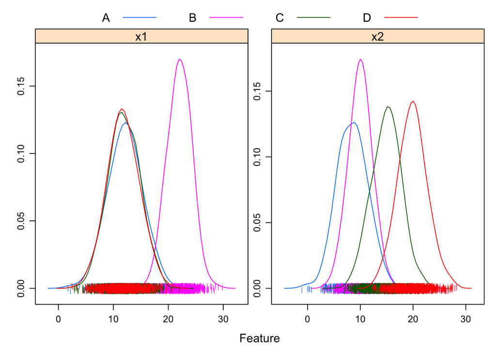

```r
library(nnet)
library(ellipse)

caret::featurePlot(x = train5[, 2:3],
            y = train5$y,
            plot = "density",
            scales = list(x = list(relation="free"),
                          y = list(relation="free")),
            adjust = 1.5,
            pch = "|",
            layout = c(2, 1),
            auto.key = list(columns = 4))
```

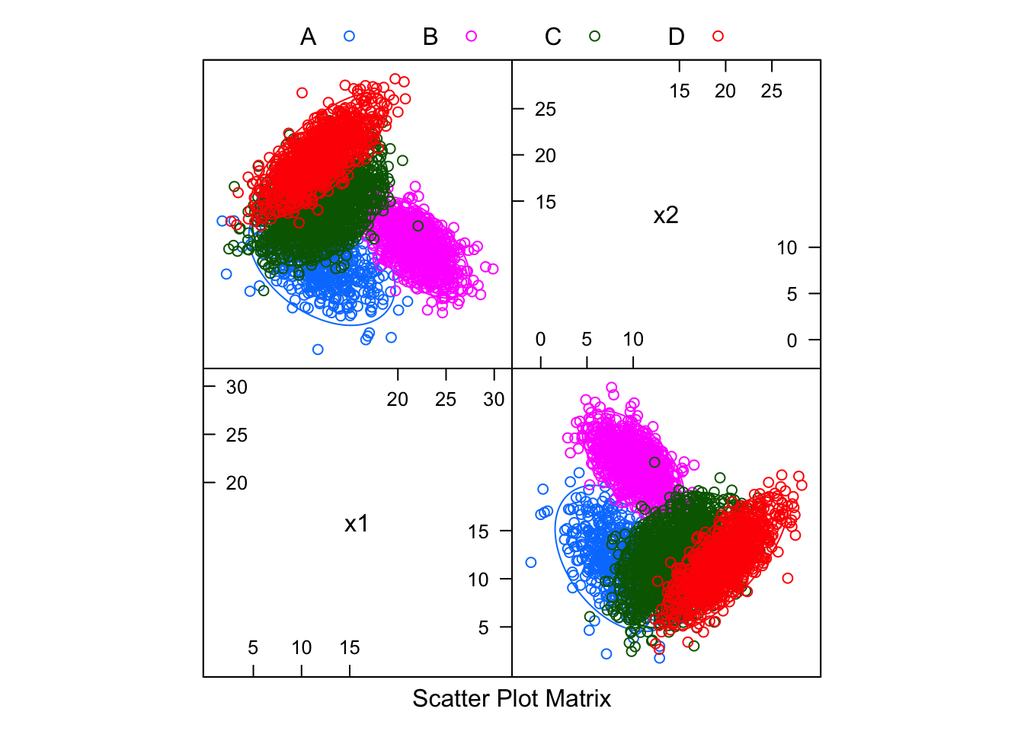

```r
caret::featurePlot(x = train5[,2:3],
                   y = train5$y,
                   plot = "ellipse",
                   auto.key = list(columns = 4))
```

```r
#Logistic
logistic = function(x1, x2) {
  calc_class_err(x2$y, predict(multinom(y ~ ., data = x1, trace = FALSE), x2))
}
#LDA
lda_error = function(x1, x2) {
  calc_class_err(x2$y, predict(lda(y ~ ., data = x1), x2)$class)
}
#LDA PRIOR
lda_prior = function(x1, x2) {
  calc_class_err(x2$y, predict(lda(
  y ~ ., data = x1, prior = c(1, 1, 1, 1) / 4
  ), x2)$class)
}
#QDA
qda_error = function(x1, x2) {
  calc_class_err(x2$y, predict(qda(y ~ ., data = x1), x2)$class)
}
#QDA PRIOR
qda_prior = function(x1, x2) {
  calc_class_err(x2$y, predict(qda(
  y ~ ., data = x1, prior = c(1, 1, 1, 1) / 4
  ), x2)$class)
}
#NAIVE BAYES
bayes = function(x1, x2) {
  calc_class_err(x2$y, predict(naiveBayes(y ~ ., data = x1), x2))
}
```

```r
#Train Error
train_error = c(logistic(train5, train5), lda_error(train5, train5), lda_prior(train5, train5), qda_error(train5, train5), qda_prior(train5, train5), bayes(train5, train5))

#Test Error
test_error = c(logistic(train5, test5), lda_error(train5, test5), lda_prior(train5, test5), qda_error(train5, test5), qda_prior(train5, test5), bayes(train5, test5))

classifier = c("Logistic",
               "LDA",
               "LDA, Flat Prior",
               "QDA",
               "QDA, Flat Prior",
               "Naive Bayes")

results = data.frame(classifier, train_error, test_error)

colnames(results) = c("Method", "Train Error", "Test Error")

knitr::kable(results)
```

| Method | Train Error | Test Error |
| --- | --- | --- |
| Logistic | 0.1482222 | 0.17425 |
| LDA | 0.1620000 | 0.19825 |
| LDA, Flat Prior | 0.1906667 | 0.16875 |
| QDA | 0.1477778 | 0.16925 |
| QDA, Flat Prior | 0.1791111 | 0.14000 |
| Naive Bayes | 0.1733333 | 0.20000 |

# Exercise 5 (Concept Checks)

**[1 point each]** Answer the following questions based on your results from the three exercises.

**(a)** Which $k$ performs best in Exercise 1?

k=5 performs best as it obatins the smallest test Test Error.

**(b)** In Exercise 4, which model performs best?

QDA with flat prior performs best as it obtains the lowest Test Error

**(c)** In Exercise 4, why does Naive Bayes perform poorly?

Here naive Bayes doesn’t get a chance to show its strength since LDA and QDA already perform well, and the number of predictors is low.

**(d)** In Exercise 4, which performs better, LDA or QDA? Why?

QDA performs better than LDA as QDA obtains a smaller test error. This is due to ΣkΣk appear to be very different for different classes.

**(e)** In Exercise 4, which prior performs better? Estimating from data, or using a flat prior? Why?

Flat prior performs better because the proportion of classes in the test data is uniform.

**(f)** In Exercise 4, of the four classes, which is the easiest to classify?

Class “B” because it does not overlap too much with other classes.

**(g)** [**Not Graded**] In Exercise 3, which classifier would be the best to use in practice?